# Stats 250: Lab 1 Assignment

Shikha Nukala

`9/13/23

### Instructions

Complete the lab exercises and Dive Deeper questions below. Lab exercises will be graded out of 2 points each and the Dive Deeper questions will be graded out of 3 points each - all of them will be graded for *correctness*. Upon completion, follow the submission instructions at the bottom of this document. We strongly encourage you to work on this assignment with a partner.

### Background

This data set contains information on *all* 801 Pokemon from the first Seven Generations of Pokemon. The variables in the data set include:

1. `primary_type`: primary type of the Pokemon (grass, fire, water, etc.)
2. `secondary_type`: secondary type of the Pokemon (poison, flying, none, etc.)
3. `legendary_status`: denotes if the Pokemon is of legendary status
4. `attack`: base attack of the Pokemon (in points)
5. `defense`: base defense of the Pokemon (in points)
6. `hp`: base HP (hit points) of the Pokemon (in points)
7. `speed`: base speed of the Pokemon (in points)
8. `special_attack`: base special attack of the Pokemon (in points)
9. `special_defense`: base special defense of the Pokemon (in points)
10. `capture_rate`: capture rate of the Pokemon (in points)
11. `base_total`: total base score of the Pokemon (in points)
12. `weight_kg`: weight of the Pokemon (in kg)*
13. `generation`: classifies the generation in which the Pokemon was introduced

*Note: some of the Pokemon do not have a weight specified and are listed as NA

[Source](https://www.kaggle.com/datasets/rounakbanik/pokemon)

Use the following code chunk to read in the data set.

```r
pokemon <- read.csv("pokemon.csv", row.names = 1)
```

And be sure to load in the required packages!

```r
library(ggplot2)
```

### Lab Exercises

After reading the background above, complete the following lab exercises. Remember, these exercises are worth 2 points each and are graded for *correctness*.

> **1.** Select a *quantitative* variable from the data set and create a histogram. Be sure to appropriately update the plot title and axis labels.

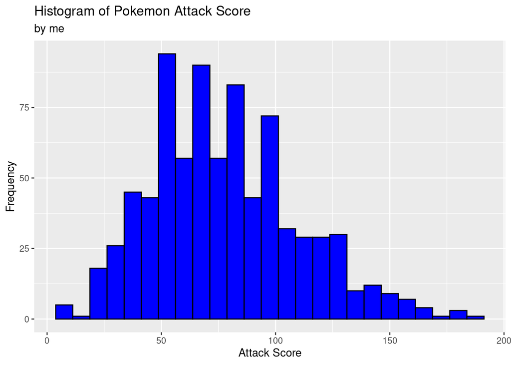

```r
ggplot(data = pokemon, aes(x = attack)) +

  geom_histogram(bins = 25,
                 color = "black",
                 fill = "blue") +

  labs(title = "Histogram of Pokemon Attack Score",
       subtitle = "by me",
       x = "Attack Score",
       y = "Frequency")
```

> **2.** Using the same variable from Exercise 1, calculate at least three useful numerical summaries that would help provide a thorough description of the variable’s distribution.

```r
IQR(pokemon$attack)
```

```
## [1] 45
```

```r
sd(pokemon$attack)
```

```
## [1] 32.15882
```

```r
median(pokemon$attack)
```

```
## [1] 75
```

> **4.** Select a *different* quantitative variable from the data set and create a histogram. Be sure to appropriately update the plot title and axis labels.

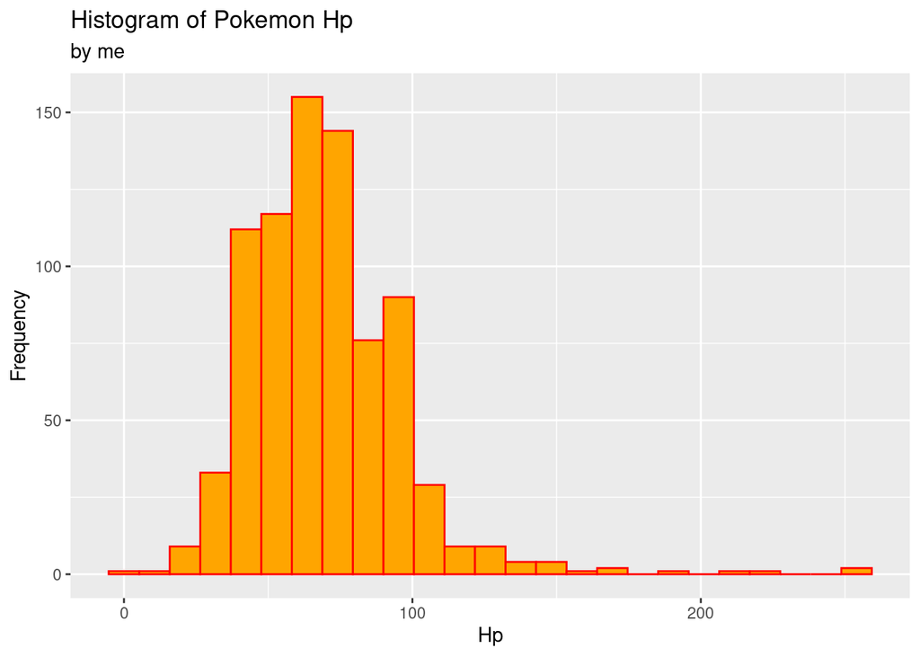

```r
ggplot(data = pokemon, aes(x = hp)) +

  geom_histogram(bins = 25,
                 color = "red",
                 fill = "orange") +

  labs(title = "Histogram of Pokemon Hp",
       subtitle = "by me",
       x = "Hp",
       y = "Frequency")
```

> **5.** Using the same variable from Exercise 4, calculate at least three useful numerical summaries that would help provide a thorough description of the variable’s distribution.

```r
mean(pokemon$hp)
```

```
## [1] 68.9588
```

```r
sd(pokemon$hp)
```

```
## [1] 26.57601
```

```r
IQR(pokemon$hp)
```

```
## [1] 30
```

> **6.** Using the histogram from Exercise 4 and the exact numerical values calculated in Exercise 5, thoroughly describe the distribution of your quantitative variable. Your response should be 2-3 sentences in length and describe at minimum the distribution’s shape, center, and spread.

*Answer:* The shape of the distribution showing hp of pokemon and the number of pokemon with a certain hp is slightly skewed right with a peak or mode at 65 hp. We can determine the slight skew as the mean of the distribution is larger than the median of the distribution. The center is a 65 hp using the median as a more accurate measure of the center considering the skew of the distribution. The spread of the distribution can be seen through the IQR with the middle 50% of the distribution spanning 30 hp roughly between 50 hp and 80 hp. We can also see the variability from the mean being 26.6 hp for the distribution and the range from 1 hp to 255 hp from the graph.

> **7.** Select a *categorical* variable from the data set and create a bar chart in the first code chunk. Be sure to appropriately update the plot title and axis labels. In the second code chunk, create a frequency table for your selected categorical variable.

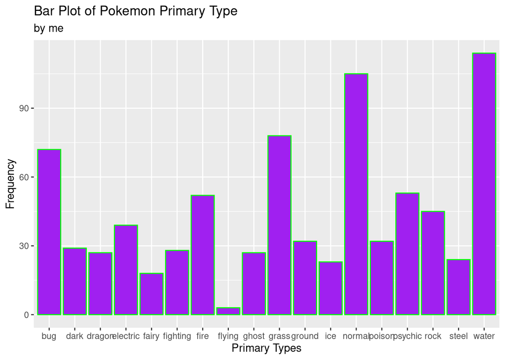

```r
ggplot(data = pokemon, aes(x = primary_type)) + geom_bar(color = "green", fill = "purple") +
  labs(title = "Bar Plot of Pokemon Primary Type", subtitle = "by me", x = "Primary Types", y = "Frequency")
```

```r
table(pokemon$primary_type)
```

```
##
##      bug     dark   dragon electric    fairy fighting     fire   flying
##       72       29       27       39       18       28       52        3
##    ghost    grass   ground      ice   normal   poison  psychic     rock
##       27       78       32       23      105       32       53       45
##    steel    water
##       24      114
```

### Dive Deeper Questions

After completing the lab exercises above, complete the following Dive Deeper questions. Remember, these questions are worth 3 points each and are graded for correctness.

> **1.** The last variable in the data set is `generation`. This variable classifies the generation in which the Pokemon was introduced. Would this variable be considered quantitative or categorical? Explain your answer in 2-3 sentences.

*Answer:* I would consider the generation variable to be a categorical variable. The generation variable represents a group of pokemon in each generation. Since pokemon are placed in generations in groups instead of measuring a value of the pokemon, this variable would be better represented in a bar plot or pie chart, which are both graphs that show association or comparison of explanatory and response variables with categorical variables.

> **2.** Propose a question that could be answered using the Pokemon data set. Your question should involve *two* variables. After stating your question, identify which variable is acting as the response variable and which variable is acting as the explanatory variable.

*Answer:* Is Legendary pokemon distinction associated with Pokemon attack score? This question would include the legendary status of pokemon and the attack score of each pokemon. The legendary status would be the explanatory variable and the attack score would be the response variable.

### Submission Instructions

Once you have finished, follow the instructions below to submit your work.

1. At the top of the document, update the `author` field. Do not change anything else at the top of the document.
2. Click the Knit button to create an HTML file of your work.
3. In the Files pane (bottom right window), check the box next to `lab01_assignment.html`.
4. In the Files pane, click on the gear icon (More) and select “Export…”
5. Do not change the file name (`lab01_assignment.html`). Click Download and save the file to your computer.
6. On the Stats 250 Canvas site, navigate to the Lab 1 assignment.
7. Upload your saved `lab01_assignment.html` file.
8. Click “Submit Assignment”. Congratulations, you are done with Lab 1!